# Pollice Killings

~ Gerardo Moreno

2020-12-17

```
##                 name age gender   raceethnicity    month day year          streetaddress         city
## 1 A'donte Washington  16   Male           Black February  23 2015           Clearview Ln    Millbrook
## 2     Aaron Rutledge  27   Male           White    April   2 2015 300 block Iris Park Dr    Pineville
## 3        Aaron Siler  26   Male           White    March  14 2015   22nd Ave and 56th St      Kenosha
## 4       Aaron Valdez  25   Male Hispanic/Latino    March  11 2015      3000 Seminole Ave   South Gate
## 5       Adam Jovicic  29   Male           White    March  19 2015         364 Hiwood Ave Munroe Falls
## 6      Adam Reinhart  29   Male           White    March   7 2015    18th St and Palm Ln      Phoenix
##   state latitude  longitude state_fp county_fp tract_ce      geo_id county_id             namelsad
## 1    AL 32.52958  -86.36283        1        51    30902  1051030902      1051  Census Tract 309.02
## 2    LA 31.32174  -92.43486       22        79    11700 22079011700     22079     Census Tract 117
## 3    WI 42.58356  -87.83571       55        59     1200 55059001200     55059      Census Tract 12
## 4    CA 33.93930 -118.21946        6        37   535607  6037535607      6037 Census Tract 5356.07
## 5    OH 41.14857  -81.42988       39       153   530800 39153530800     39153    Census Tract 5308
## 6    AZ 33.46938 -112.04332        4        13   111602  4013111602      4013 Census Tract 1116.02
##              lawenforcementagency   cause   armed  pop share_white share_black share_hispanic p_income
## 1     Millbrook Police Department Gunshot      No 3779        60.5        30.5            5.6    28375
## 2 Rapides Parish Sheriff's Office Gunshot      No 2769        53.8        36.2            0.5    14678
## 3       Kenosha Police Department Gunshot      No 4079        73.8         7.7           16.8    25286
## 4    South Gate Police Department Gunshot Firearm 4343         1.2         0.6           98.8    17194
## 5          Kent Police Department Gunshot      No 6809        92.5         1.4            1.7    33954
## 6       Phoenix Police Department Gunshot      No 4682           7         7.7             79    15523
##   h_income county_income comp_income county_bucket nat_bucket  pov      urate    college
## 1    51367         54766   0.9379359             3          3 14.1 0.09768638 0.16850951
## 2    27972         40930   0.6834107             2          1 28.8 0.06572379 0.11140236
## 3    45365         54930   0.8258693             2          3 14.6 0.16629314 0.14731227
## 4    48295         55909   0.8638144             3          3 11.7 0.12482727 0.05013293
## 5    68785         49669   1.3848678             5          4  1.9 0.06354983 0.40395421
## 6    20833         53596   0.3887044             1          1   58 0.07365145 0.10295519
```

```
##   id               name       date  manner_of_death      armed age gender race          city state
## 1  3         Tim Elliot 2015-01-02             shot        gun  53      M    A       Shelton    WA
## 2  4   Lewis Lee Lembke 2015-01-02             shot        gun  47      M    W         Aloha    OR
## 3  5 John Paul Quintero 2015-01-03 shot and Tasered    unarmed  23      M    H       Wichita    KS
## 4  8    Matthew Hoffman 2015-01-04             shot toy weapon  32      M    W San Francisco    CA
## 5  9  Michael Rodriguez 2015-01-04             shot   nail gun  39      M    H         Evans    CO
## 6 11  Kenneth Joe Brown 2015-01-04             shot        gun  18      M    W       Guthrie    OK
##   signs_of_mental_illness threat_level        flee body_camera
## 1                    True       attack Not fleeing       False
## 2                   False       attack Not fleeing       False
## 3                   False        other Not fleeing       False
## 4                    True       attack Not fleeing       False
## 5                   False       attack Not fleeing       False
## 6                   False       attack Not fleeing       False
```

# Where do the police killings tend to happen more frequently?

Using the “police_killings.csv” data I will analyze where these police killings tend to happen more frequently, looking for trends like if there is a state with notably more killings than other states. I will preform this analysis with grouping, filtering, and creating a spacial map with ggplot to visualize my analysis.

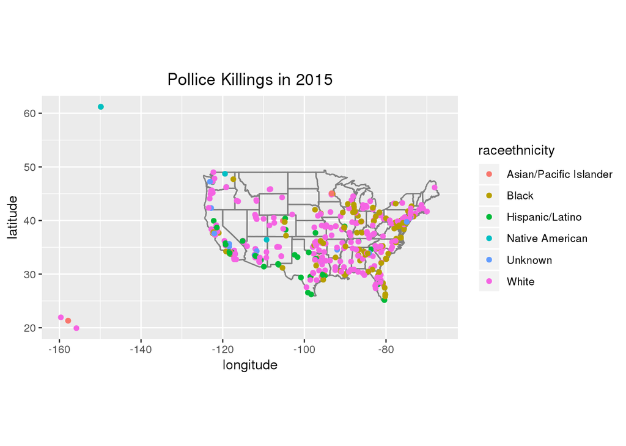

```r
police2 %>% ggplot(aes(longitude, latitude, color = raceethnicity)) + borders("state") + geom_point() + coord_quickmap() +
    ggtitle("Pollice Killings in 2015") + theme(plot.title = element_text(hjust = 0.5))
```

In the graph above, the points show where the killing exactly occured in United States in the year of 2015 alone. I plotted the longitude on the x axis and latitude on the y axis, and the results shows that there were more police killings on the east side of the United States compared to the West. I also colored the dots to show what race was being killed.

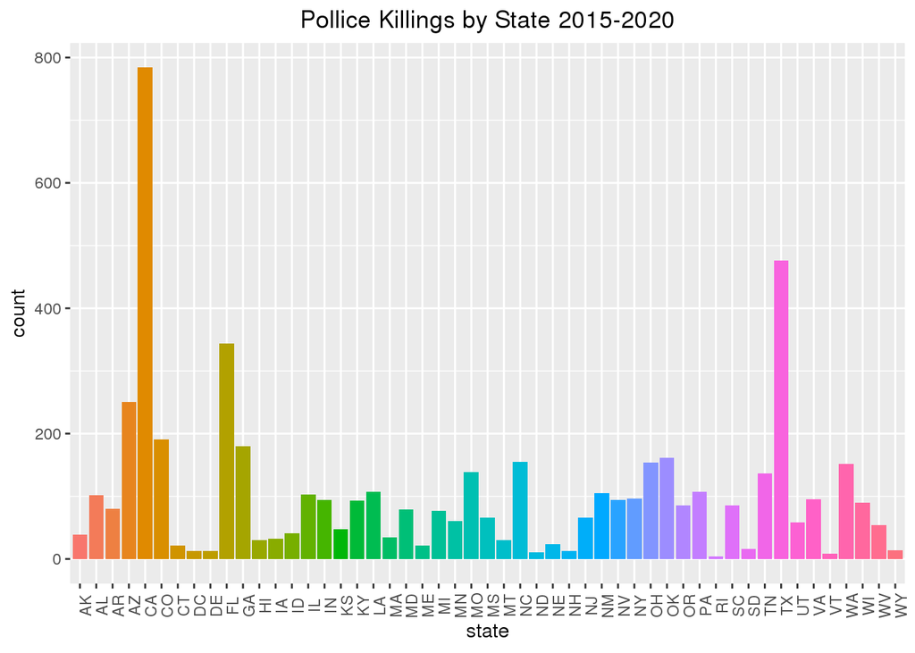

```r
police4 %>% ggplot(aes(x = state, fill = state)) + geom_bar() + theme(legend.position = "none") + theme(axis.text.x = element_text(angle = 90)) +
    ggtitle("Pollice Killings by State 2015-2020") + theme(plot.title = element_text(hjust = 0.5))
```

In the graph above, I was wanting to answer the question of which states tend to have the most police killings. From the results, it shows that California has significantly more police killings than any other state in the United States. This could be of many reason, for example population, size of police task force, and even the crime rate. The two states with the most fatal police killings are also the two most populated states in the United States.

#Who tend to be killed more often by police officers?

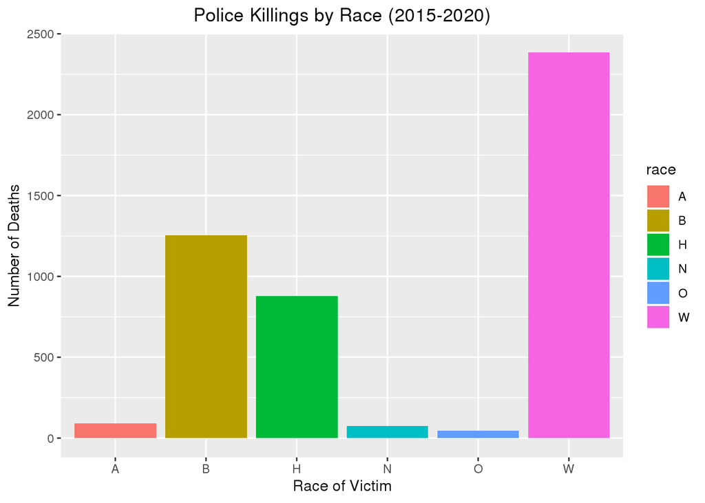

```r
police4 %>% filter(race != "") %>% ggplot(aes(x = race, fill = race)) + geom_bar() + ggtitle("Police Killings by Race (2015-2020)") +
    theme(plot.title = element_text(hjust = 0.5)) + ylab("Number of Deaths") + xlab("Race of Victim")
```

```r
head(police4)
```

```
##   id               name       date  manner_of_death      armed age gender race          city state
## 1  3         Tim Elliot 2015-01-02             shot        gun  53      M    A       Shelton    WA
## 2  4   Lewis Lee Lembke 2015-01-02             shot        gun  47      M    W         Aloha    OR
## 3  5 John Paul Quintero 2015-01-03 shot and Tasered    unarmed  23      M    H       Wichita    KS
## 4  8    Matthew Hoffman 2015-01-04             shot toy weapon  32      M    W San Francisco    CA
## 5  9  Michael Rodriguez 2015-01-04             shot   nail gun  39      M    H         Evans    CO
## 6 11  Kenneth Joe Brown 2015-01-04             shot        gun  18      M    W       Guthrie    OK
##   signs_of_mental_illness threat_level        flee body_camera
## 1                    True       attack Not fleeing       False
## 2                   False       attack Not fleeing       False
## 3                   False        other Not fleeing       False
## 4                    True       attack Not fleeing       False
## 5                   False       attack Not fleeing       False
## 6                   False       attack Not fleeing       False
```

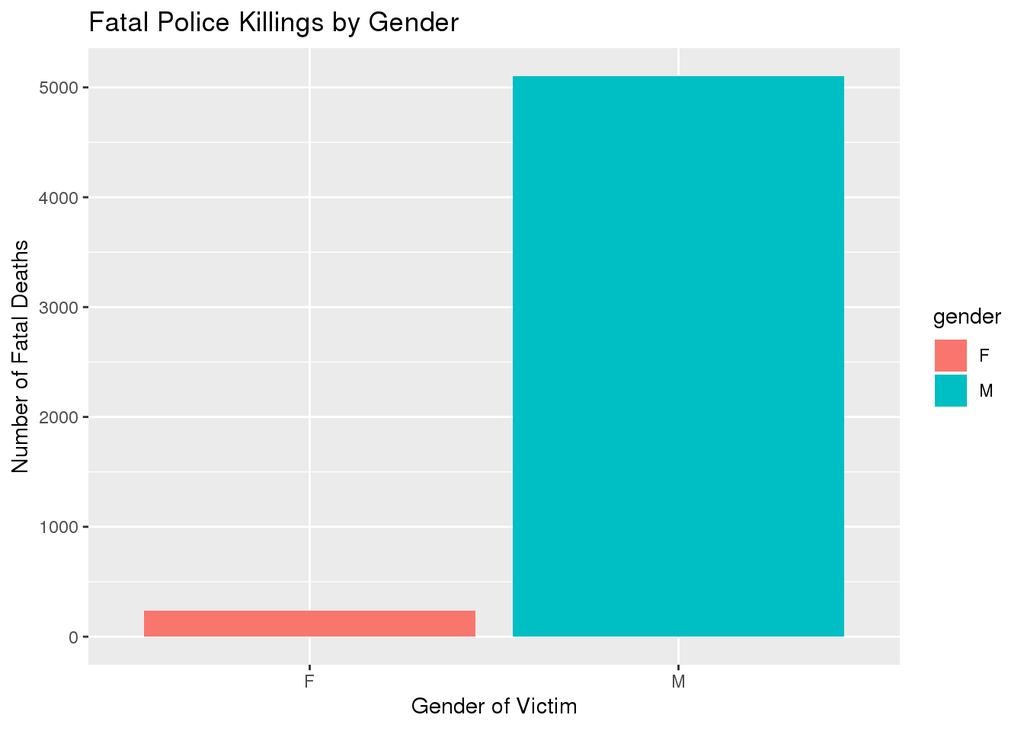

```r
police4 %>% filter(gender != "") %>% ggplot(aes(gender, fill = gender)) + geom_bar() + xlab("Gender of Victim") +
    ylab("Number of Fatal Deaths") + ggtitle("Fatal Police Killings by Gender")
```

#How are victims getting killed?

Using the dataset, I will be asking questions like of how victims are getting killed by police, taking into consideration if the police officer felt threatened, if body cameras were utilized, and if the victim tried to flee.

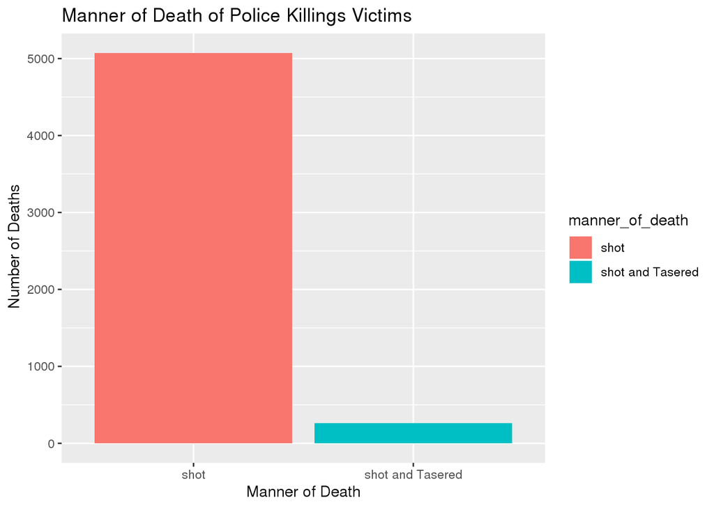

```r
police4 %>% ggplot(aes(manner_of_death, fill = manner_of_death)) + geom_bar() + ggtitle("Manner of Death of Police Killings Victims") +
    xlab("Manner of Death") + ylab(" Number of Deaths")
```

As the results shown above by the graph, it tends to show that victim are mostly always killed by being shot. The two variable are quite similar, as the only difference is that if a taser would have been involved in the death.

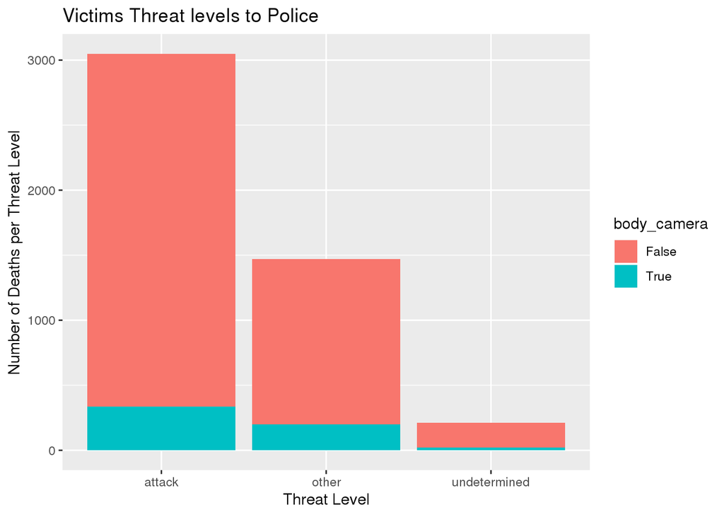

```r
police4 %>% filter(race != "") %>% ggplot(aes(threat_level, fill = body_camera)) + geom_bar() + ggtitle("Victims Threat levels to Police") +
    xlab("Threat Level") + ylab("Number of Deaths per Threat Level")
```

The victim of police killings tend to be killed more often if they are considered to be to show an “attack” to the police officer. There could be many reasons of this, and one of those reasons could be that the definition of an “attack” could be different to person to person. So, there could be no way to draw a definite conclusion to this question. Though, I was able to fill the bars of data of each threat level to determine if there was body camera footage to the police killing. I noticed that in most deaths the police were not using the cameras or were turned off. The results of this analysis surprised me as the years of this data was being collected from 2015-2020, which I would suppose that the majority of cops would have a body camera at that point of time.

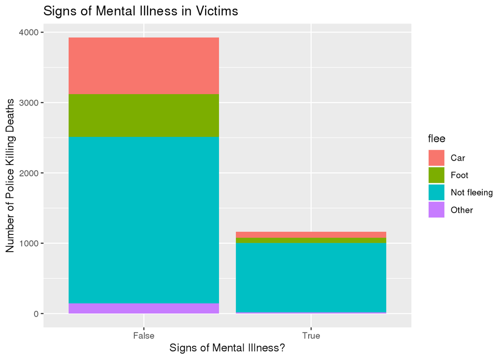

```r
police4 %>% filter(flee != "") %>% ggplot(aes(x = signs_of_mental_illness, fill = flee)) + geom_bar() + ggtitle("Signs of Mental Illness in Victims") +
    xlab("Signs of Mental Illness?") + ylab("Number of Police Killing Deaths")
```

In my analysis above, the graph answers the question if the victims of the police killings showed signs of mental illness. Along with comparing these in a bar chart, I filled the chart to show if the victim tried to flee, and if so how they did so. Regardless, from the data, there shows to be more victim deaths if they did not show signs of mental illness.

#Conclusion

In conclusion, while this data set doesn’t capture the United State’s full history of police violence, this does offer important information on trends that occurred in the passed 5 years. It is important to recognize which race groups and genders tend to be killed more, as data might not complete show the complete picture. Also, noting that the views of this dat could potentially be biased, as the other side of the story is unable to be told.